# Notes - Douglas Luke, A User’s Guide to Network Analysis in R

Mustafa Ascha

August 21, 2016

## Chapter 2

Jacob Moreno collected data on friendship networks of fourth graders (in the 1930s lol). Here’s a visualization, according to gender:

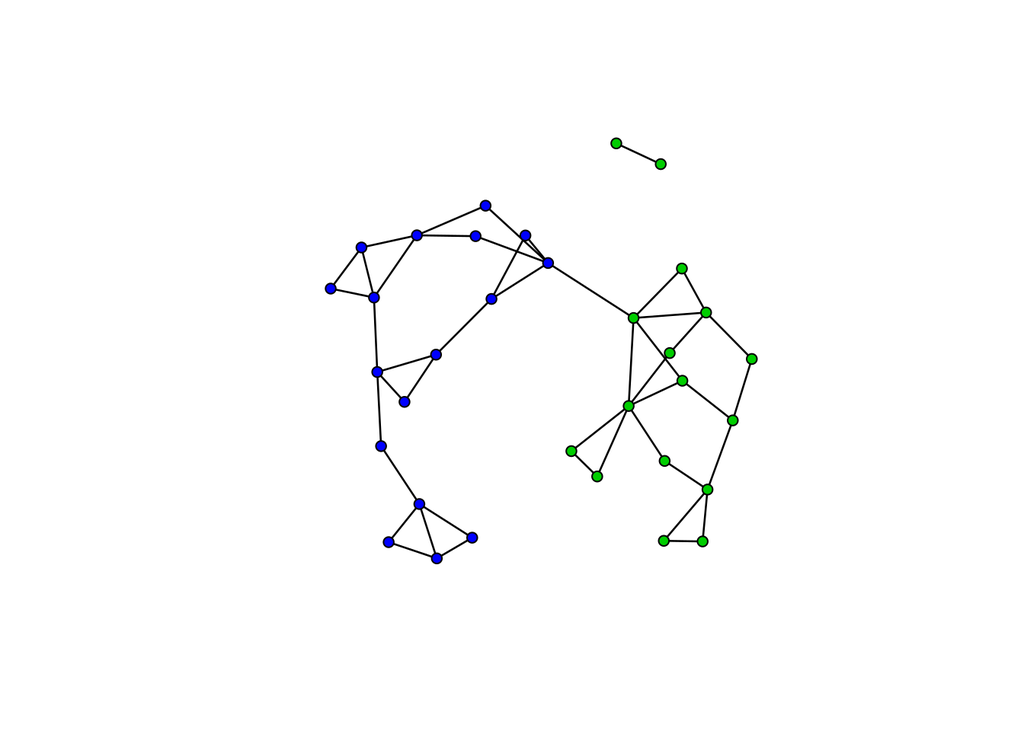

```r
data(Moreno)

gender <- Moreno %v% "gender"

plot(Moreno, vertex.col = gender + 2, vertex.cex = 1.2)
```

Okay, so that’s hilarious. It looks like there was only one pair of boy-girl friends.

## Describing the previous network

Use the following: * Size (number of nodes) * Density (Proportion of potential connections) * Components (Number of distinct sub-networks) * Diameter (Compactness) * Clustering Coefficient

```r
summary(Moreno, print.adj = FALSE)
```

```
## Network attributes:
##   vertices = 33
##   directed = FALSE
##   hyper = FALSE
##   loops = FALSE
##   multiple = FALSE
##   bipartite = FALSE
##  total edges = 46
##    missing edges = 0
##    non-missing edges = 46
##  density = 0.08712121
##
## Vertex attributes:
##
##  gender:
##    numeric valued attribute
##    attribute summary:
##    Min. 1st Qu.  Median    Mean 3rd Qu.    Max.
##   1.000   1.000   2.000   1.515   2.000   2.000
##   vertex.names:
##    character valued attribute
##    33 valid vertex names
##
## No edge attributes
```

33 is the network **size** of Moreno. The previous summary shows some of the other attributes.

Note that the maximum number of edges among nodes in a **directed** graph is *k* `*` *(k - 1)*. Where *L* is the number of observed edges, the **density** is *L* / *k* `*` *(k - 1)*.

Similarly the maximum number of edges among nodes in an **undirected** graph is *(k* `*` *(k - 1)) / 2*. Where *L* is the number of observed edges, the **density** is *2L* / *k* `*` *(k - 1)*.

0.0871212 is the network **density** of Moreno.

A component is a type of subgroup, though there are many other ways to define a subgroup. A component is defined as a group of nodes that has no connections to any other nodes. There are 2 **components** in Moreno.

Diameter is another interesting measure. Of the shortest paths across all pairs of nodes, the longest is called the diameter. This is a worst-case scenario for the transferral of information, so it kinda represents the farthest a message could travel if everyone wanted to send messages to everyone else. A shortest path is called a “geodesic”, so the diameter is the maximum geodesic. The **diameter** of Moreno is 11.

To understand the clustering coefficient, first consider closure: closure is the process whereby two people who share a common friend become friends, themselves. This is measured in terms of *transitivity*, which is the proportion of closed three-person relationships to the proportion of all three-person relationships. The **transitivity** of Moreno is 0.2857143. This is one type of clustering coefficient.

## Chapter 3